# cm014 Worksheet: The Model-Fitting Paradigm in R

So you want to fit a model to your data. How can you achieve this with R?

Topics:

1. What *is* model-fitting?
2. How do we fit a model in R?
3. How can we obtain tidy results from the model output?

## What is Model-Fitting?

When variables are not independent, then we can gain information about one variable if we know something about the other.

Examples: Use the scatterplot below:

1. A car weighs 4000 lbs. What can we say about its mpg?
2. A car weights less than 3000 lbs. What can we say about its mpg?

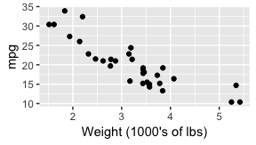

Example: What can we say about rear axle ratio if we know something about quarter mile time?

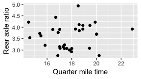

If EDA isn’t enough, we can answer these questions by fitting a model: a curve that predicts Y given X. Aka, a **regression curve** or a **machine learning model**.

(There are more comprehensive models too, such as modelling entire distributions, but that’s not what we’re doing here)

There are typically two goals of fitting a model:

1. Make predictions.
2. Interpret variable relationships.

## Fitting a model in R

Model fitting methods tend to use a common format in R:

```
method(formula, data, options)
```

They also tend to have a common output: a special *list*.

**Method**:

A function such as:

- Linear Regression: `lm`
- Generalized Linear Regression: `glm`
- Local regression: `loess`
- Quantile regression: `quantreg::rq`
- …

**Formula**:

In R, takes the form `y ~ x1 + x2 + ... + xp` (use column names in your data frame).

**Data**: The data frame.

**Options**: Specific to the method.

Exercise:

1. Fit a linear regression model to life expectancy (“Y”) from log(GDP per capita) (“X”) by filling in the formula. Notice what appears as the output.
2. On a new line, use the `unclass` function to uncover the object’s true nature: a list. Note: it might be easier to use the `names` function to see what components are included in the list.

```r
unclass(my_lm)
```

[output not shown]

[output cut: 1224 more lines]

[output not shown]

[output not shown]

[output cut: 990 more lines]

```
NA
```

To complicate things further, some info is stored in *another* list after applying the `summary` function:

```r
summary(my_lm) %>%
  names()
```

```
 [1] "call"          "terms"         "residuals"     "coefficients"  "aliased"       "sigma"
 [7] "df"            "r.squared"     "adj.r.squared" "fstatistic"    "cov.unscaled"
```

We can use the `predict()` function to make predictions from the model (default is to use fitting/training data). Here are the predictions:

```r
predict(my_lm, newdata = tibble(gdpPercap = c(500,600,700)))
```

```
       1        2        3
43.13342 44.66585 45.96150
```

We can plot models (with one predictor/ X variable) using `ggplot2` through the `geom_smooth()` layer. Specifying `method="lm"` gives us the linear regression fit (but only visually!):

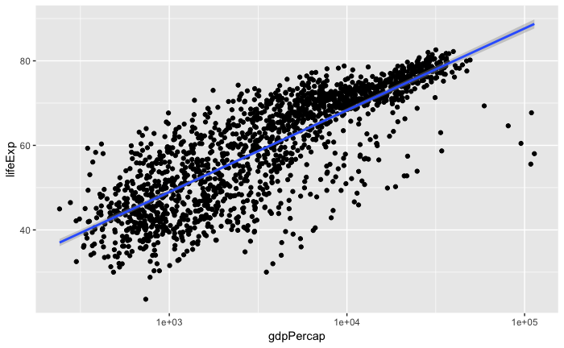

## Broom

Let’s make it easier to extract info, using the `broom` package. There are three crown functions in this package, all of which input a fitted model, and outputs a tidy data frame.

1. `tidy`: extract statistical summaries about each component of the model.
   - Useful for *interpretation* task.
2. `augment`: add columns to the original data frame, giving information corresponding to each row.
   - Useful for *prediction* task.
3. `glance`: extract statistical summaries about the model as a whole (1-row tibble).
   - Useful for checking goodness of fit.

Exercise: apply all three functions to our fitted model, `my_lm`. What do you see?

|  | r.squared | adj.r.squared | sigma | statistic | p.value | df | logLik | AIC | BIC | deviance | df.residual |
| --- | --- | --- | --- | --- | --- | --- | --- | --- | --- | --- | --- |
| 1 | 0.6522466 | 0.6520423 | 7.619535 | 3192.273 | 0 | 2 | -5877.21 | 11760.42 | 11776.74 | 98813.56 | 1702 |